# introduction

## Introduction

This R Shiny application is build on the R package [`NpsychBatteryNorms`](https://rmtrane.github.io/NpsychBatteryNorms), which implements a handful of methods to standardize various neuropsychological scores. The main focus is to standardize scores that are part of UDS 3, but some legacy and a few additional scores are included as well.

## General Workflow

On the “Scoring Tables and Figures” tab, you will find tables and figures showing the scores of participants at different visits and longitudinally. Many of these are interaction. As a few examples, you can zoom in/out and select/deselect scores on the plots, and error codes in the summary table (highlighted with red text and underlined) will show description when hovered.

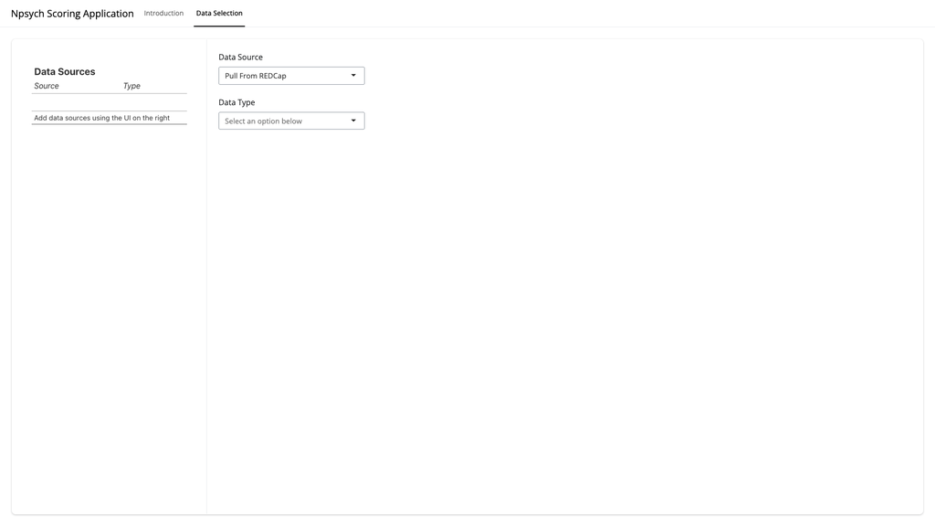

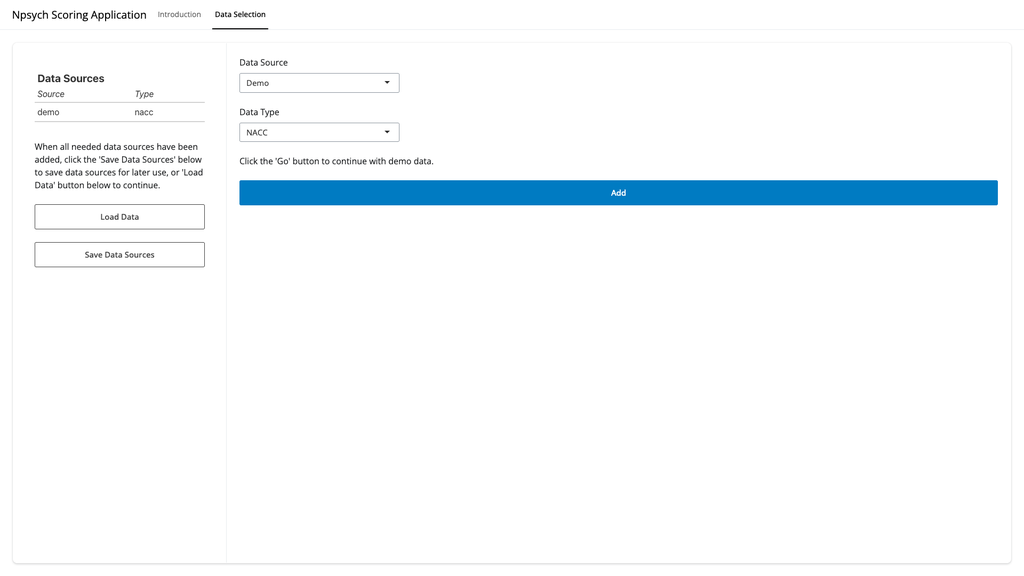

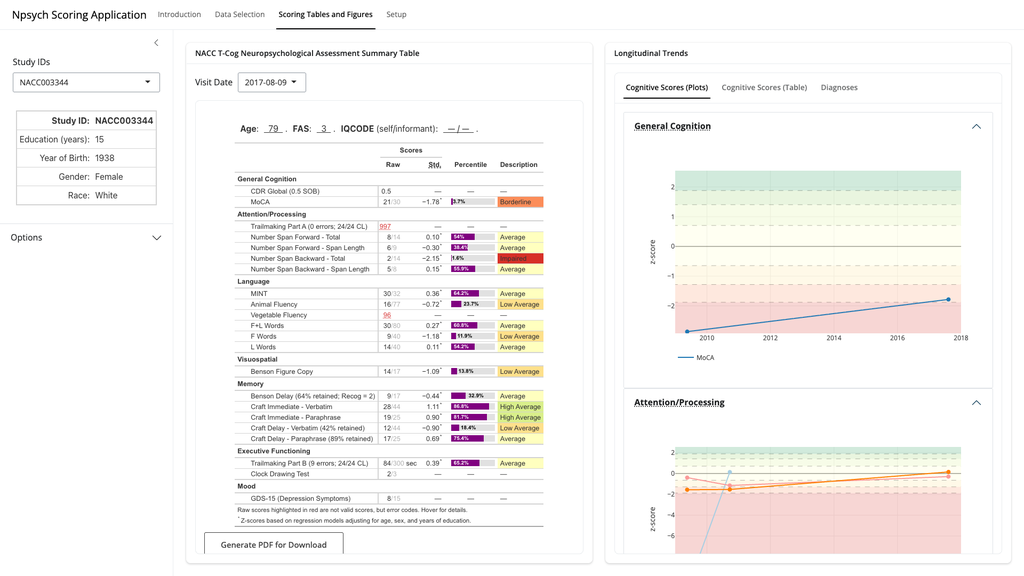

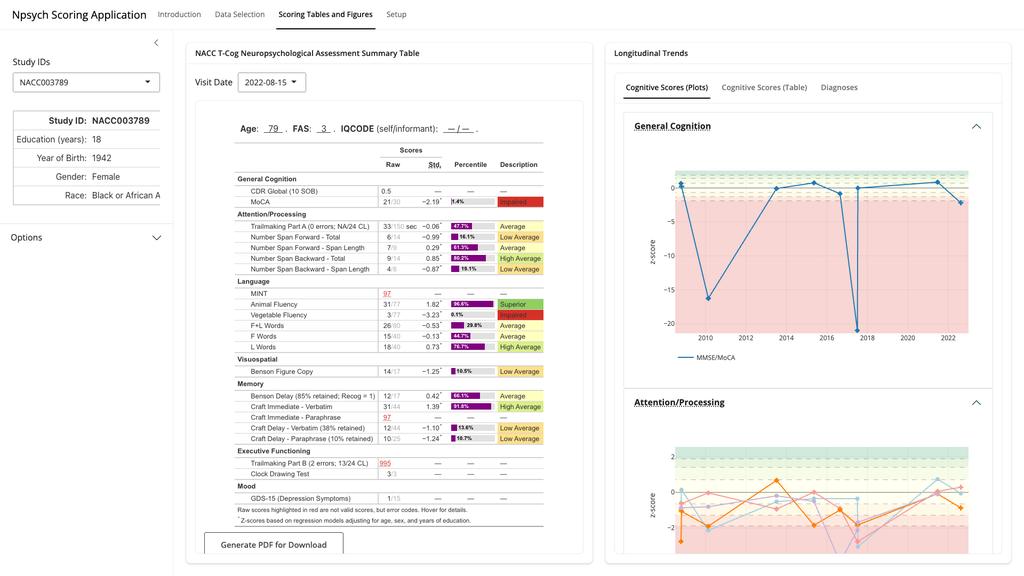

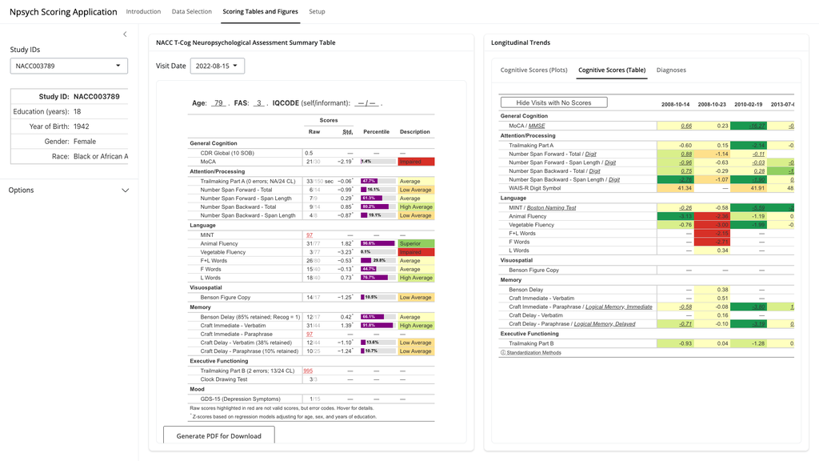

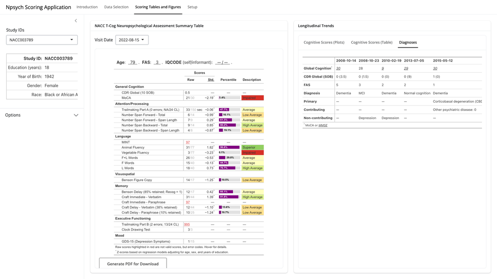

## Standardization Methods

Multiple standardization methods are implemented in the R-package [`NpsychBatteryNorms`](https://rmtrane.github.io/NpsychBatteryNorms), though not all methods are available for all variables. Table 1 lists all variables that can be standardization and all methods available.

As of now, we distinguish between three different methods, two of which are implemented in two different versions:

- `norms` refers to the practice of standardizing to z-scores using summary statistics from a normative sample. We have two versions of this method: “NACC” uses the [summary statistics published by NACC](https://files.alz.washington.edu/documentation/uds3-means.pdf), (which are described in Weintraub et al. (2018)) while “Updated” tries to recalculate the summary statistics with the June 2024 data lock.
- `regression` refers to the practice of standardizing to z-scores using a an estimated average and standard deviation derived from a regression model fitted to a normative sample. We have multiple versions: “NACC” uses the regression model published by Weintraub et al. (2018), while “Updated (`X Y`)” tries to refit the same model to an updated normative sample using the data lock from month `X` of year `Y`.
- `T-score` refers to the models presented in Stricker et al. (2021) and Karstens et al. (2024).

Default methods are underlined in Table 1. Not all variables have default methods. This is because some variables are not used standardized in this application. The user can change the standardization methods used on the “Setup” tab once data has been loaded.

Table 1: Implemented standardization methods for variables. `short_descriptor` is the short description included in the RDD while `norms`, `regression`, and `T-score` columns refer to implemented methods.

[output not shown]

[output cut: 46 more lines]

## References

Karstens, Aimee J., Teresa J. Christianson, Emily S. Lundt, Mary M. Machulda, Michelle M. Mielke, Julie A. Fields, Walter K. Kremers, et al. 2024. “Mayo Normative Studies: Regression-Based Normative Data for Ages 30–91 Years with a Focus on the Boston Naming Test, Trail Making Test and Category Fluency.” *Journal of the International Neuropsychological Society : JINS* 30 (4): 389–401. https://doi.org/10.1017/S1355617723000760.

Stricker, Nikki H., Teresa J. Christianson, Emily S. Lundt, Eva C. Alden, Mary M. Machulda, Julie A. Fields, Walter K. Kremers, et al. 2021. “Mayo Normative Studies: Regression-Based Normative Data for the Auditory Verbal Learning Test for Ages 30–91 Years and the Importance of Adjusting for Sex.” *Journal of the International Neuropsychological Society* 27 (3): 211–26. https://doi.org/10.1017/S1355617720000752.

Weintraub, Sandra, Lilah Besser, Hiroko H. Dodge, Merilee Teylan, Steven Ferris, Felicia C. Goldstein, Bruno Giordani, et al. 2018. “Version 3 of the Alzheimer Disease Centers’ Neuropsychological Test Battery in the Uniform Data Set (UDS).” *Alzheimer Disease & Associated Disorders* 32 (1): 10–17. https://doi.org/10.1097/WAD.0000000000000223.